# Project Report: Heart Attack Indicators 2023

SLB

Author

Fauzan Aryaputra, Ethan Sterling, Daniel Leshem, Joel Kim

Published

December 4, 2023

Abstract

*This project investigates a CDC dataset to comprehensively understand U.S. public health. Our primary focus is on exploring the relationship between individuals’ profiles and heart attack risks. We also look into problems of disproportionate healthcare access in the U.S. Current risk assessment tools, including the Mayo Clinic calculator, lack specificity. Our goal is to pinpoint the factors correlated with heart attacks, aiming to inform stakeholders on effective risk reduction strategies. Through a meticulous dataset analysis, we seek to contribute evidence-based insights for shaping policies and interventions, ultimately working towards reducing the prevalence of heart attacks and enhancing overall cardiovascular health in the U.S. population*.

## 1 Background / Motivation

The decision to explore the dataset stems from a deep interest in understanding and addressing critical aspects of public health in the United States. The dataset, originating from the Centers for Disease Control and Prevention (CDC), provides a comprehensive overview of the health status of U.S. residents.

More specifically, we are interested in exploring the relationship between individuals’ profiles and their heart attack risks. We found that heart attack risk information was either too vague or not specific enough; the Mayo clinic heart attack likelihood online calculator barely asks any questions about an individuals’ profile. Heart attacks and heart attack deaths are on the decline in society, but yet they still remain as one of the leading causes of death, according to the CDC. We wanted to understand what exactly correlates with heart attacks and seek to inform our stakeholders on how we as a society can reduce our risk of heart attacks.

## 2 Problem statement

1. Which demographic groups are most susceptible to heart attacks?
2. Are there significant racial and ethnic disparities in who can access checkups?
3. How do lifestyle choices correlate with the occurrence of heart attacks among individuals in the dataset?
4. How do underlying health issues and vaccination statuses impact the risk of heart attacks and heart disease?

## 3 Data sources

The dataset is sourced from the CDC and constitutes a significant component of the Behavioral Risk Factor Surveillance System (BRFSS). BRFSS, initiated in 1984 with participation from 15 states, has expanded to encompass all 50 states, the District of Columbia, and three U.S. territories. Conducting annual telephone surveys, BRFSS gathers health-related data from U.S. residents. With over 400,000 adult interviews conducted each year, it stands as the world’s largest continuously administered health survey system. The latest dataset incorporates information from the year 2023.

This particular dataset has been transformed by a Kaggle user (Kamil Pytlak) who changed the variable names into usable ones. The Kaggle link is here: https://www.kaggle.com/datasets/kamilpytlak/personal-key-indicators-of-heart-disease

## 4 Stakeholders

The main stakeholders are individuals living in the US and its territories with major risk factors, the healthcare sector, ethnic and racial minorities, and state governments. By identifying risk factors, we can provide the healthcare sector with a better framework for assessing individuals’ heart attack risk. Additionally, by identifying which racial and ethnic groups are at the highest risk, state and local governments can make policies that allocate resources to help eliminate racial disparities in the healthcare sector.

## 5 Data quality check / cleaning / preparation

*As a group, we decided to do our own data quality check and prep, as we felt that the variables we focused on had their own methods for cleaning and we didn’t want to lose precision/accuracy in accidentally cleaning others’ data. Our check is at the top of our respective EDAs.*

## 6 Exploratory Data Analysis

### 6.1 Demographic Analysis

*By Daniel Leshem*

To get a good understanding of the dataset and its content, we decided to first look at the demographics of the different individuals surveyed by the CDC. It is important that medical databases are representative so that our findings can be generalized to the larger population without bias. So, before anything else, I created a bar chart to visualize the demographics of the Americans surveyed.

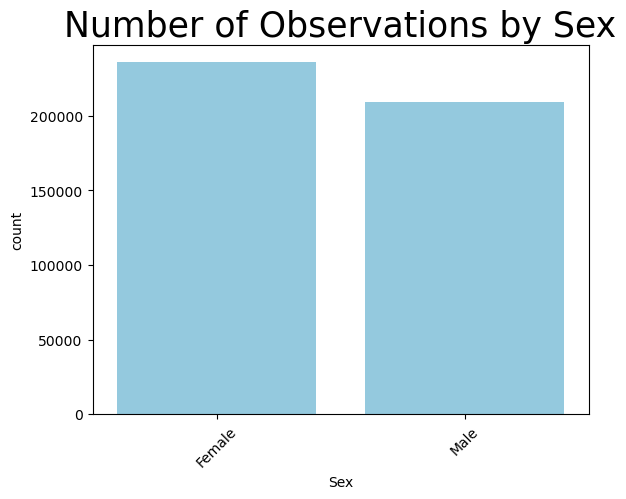

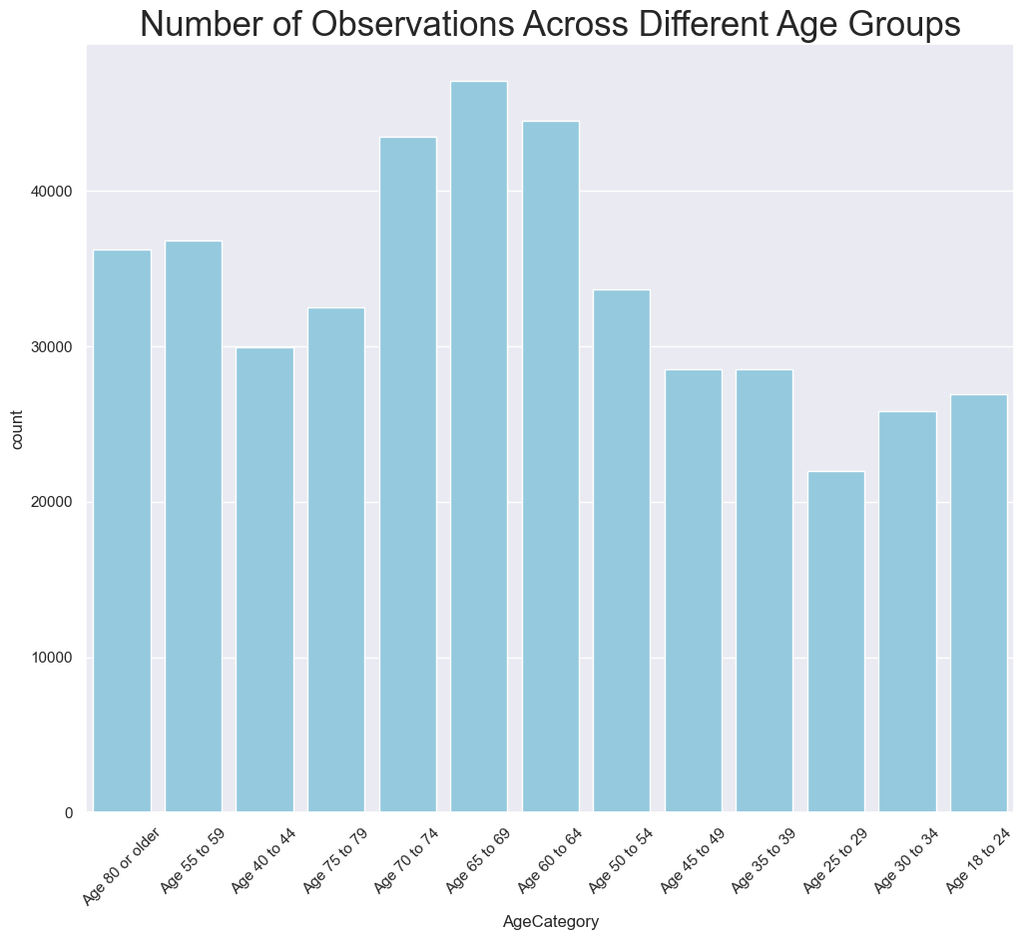

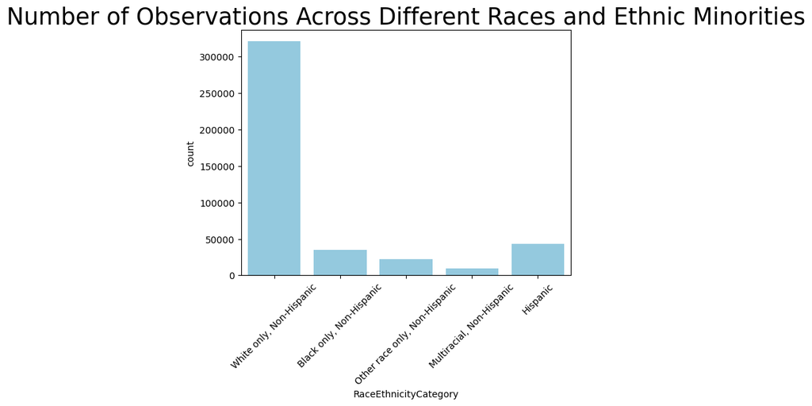

Looking at the charts, we can see that the dataset is not perfectly representative of the American population. Looking specifically at the race and sex variables, our survey data is not representative of the population. Of those surveyed, 72% were white only, non-hispanic whereas 59.3% of the American population is white only, non-hispanic. Additionally, 53% of survey respondents were female, as compared with 51.1% of the United States population.

Next, we wanted to examine which demographics are more likely to experience a cardiac event. An understanding of racial disparities in heart attack risk will help us understand what genetic and environmental factors are associated most with cardiac events. For our examination, first divided the observations by race and ethnicity. Then, we calculated and graphed the share of individuals in each group that had a heart attack.

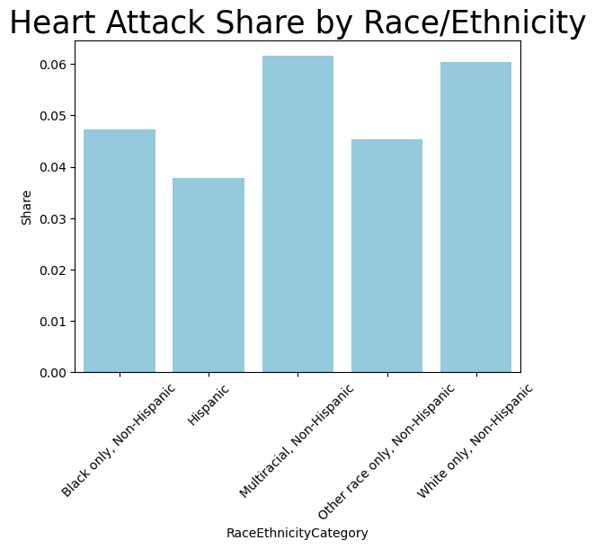

From our analysis, we saw that multiracial and white individuals tend to have the most heart attacks. Of those surveyed, 6% of multiracial and white individuals had heart attacks, compared with 4% of hispanic individuals. To verify this, we ran a chi-squared test and determined that there is a statistically significant difference between these populations. Moving forward, we decided to look at the same breakdown but by sex.

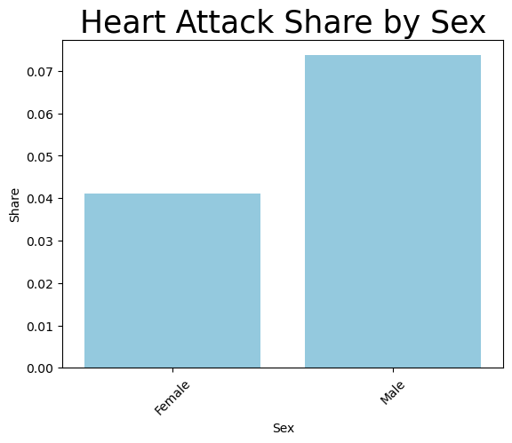

7% of the males surveyed had heart attacks, compared to 4% of females. Once again, we verified this result with a t-test and determined that these differences are statistically significant. Finally, we wanted to examine whether these discrepancies hold when we control for race. To do that, we filtered the observations by individuals that do and do not belong to a racial minority. Next, we looked at the same sex disparities.

[figure not shown]

[figure not shown]

When we get granular with our approach, the data tells the same story. Regardless of race, males tend to be at a higher heart attack risk than females.

Lastly, we looked at how heart attack risk is distributed by age. As age increases, so does heart attack risk. Of those in the oldest age bin, more than 14% experienced a cardiac event, compared with 0.3% of those in the youngest bin.

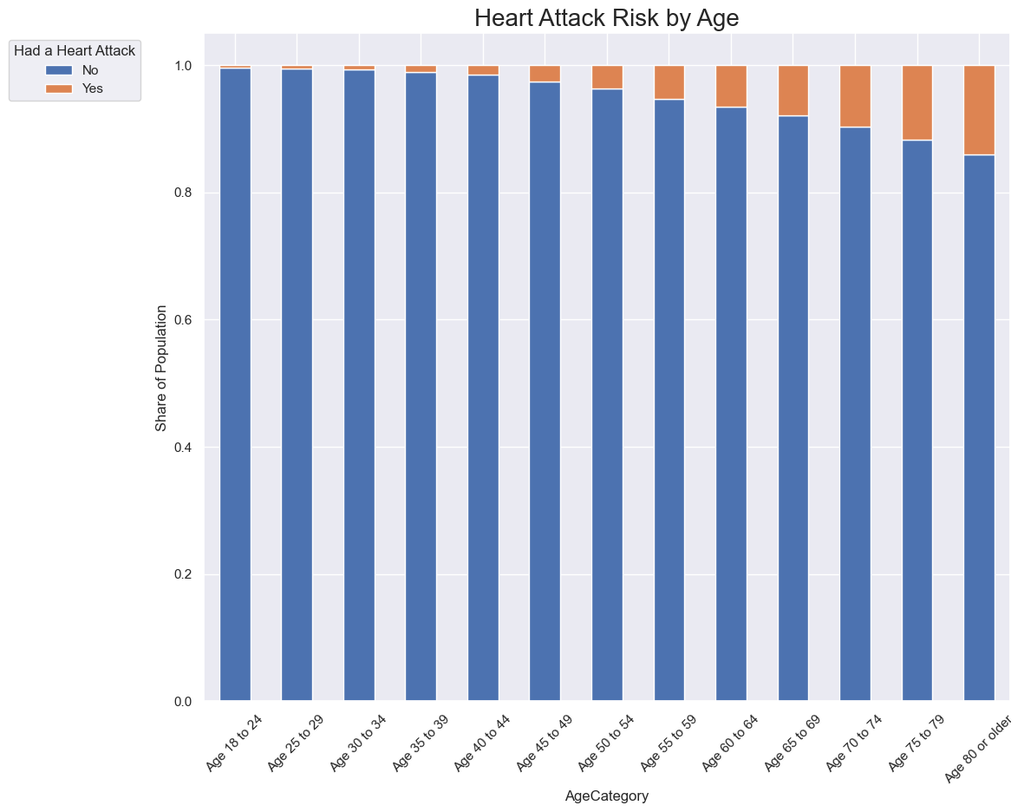

### 6.2 Access Analysis

*By Joel Kim*

|  | LastCheckupTime | HadHeartAttack | RaceEthnicityCategory |
| --- | --- | --- | --- |
| 0 | < 1 year | No | White only, Non-Hispanic |
| 1 | NaN | No | White only, Non-Hispanic |
| 2 | < 1 year | No | White only, Non-Hispanic |
| 3 | < 1 year | No | White only, Non-Hispanic |
| 4 | < 1 year | No | White only, Non-Hispanic |

I worked to determine if there were any racial and ethnic disparities in accessing checkups based on the dataset. This involved focusing on the ‘LastCheckupTime’ column, which detailed how recently each person had their most recent checkup, categorized into four possible groups. I then compared this to the ‘RaceEthnicityCategory’, which indicated the race and ethnicity of each individual, to discern any correlation between the two columns. My initial thought was that if certain racial or ethnic groups had significantly less recent checkups than others, it might indicate a real disparity in their ability to access healthcare.

Originally, I plotted a stacked bar chart representing the five different race and ethnicity categories. Each bar was divided into percentages for the four recency groups of checkups.

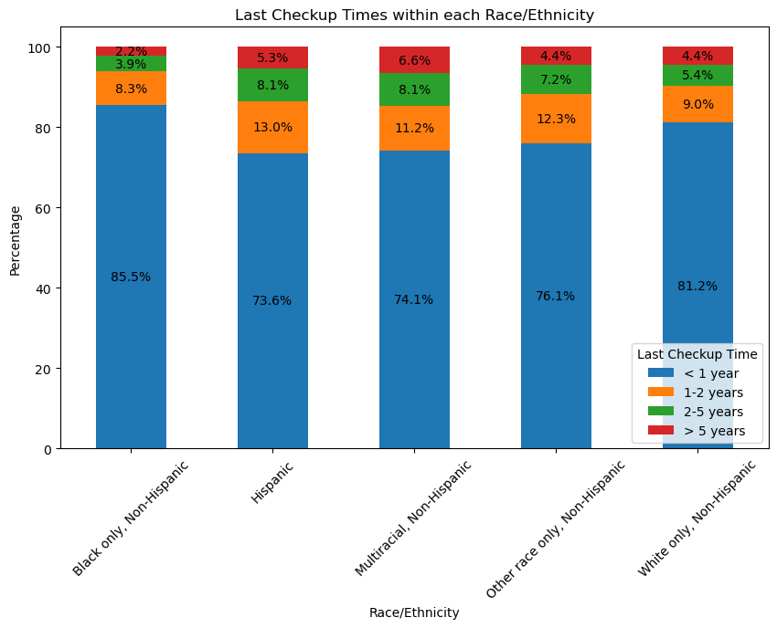

The five race and ethnicity categories are Black, Hispanic, White, multiracial, and other race. The four checkup recency categories are within a year, 1-2 years, 2-5 years, and over 5 years.

However, I hypothesized that ‘HadHeartAttack’, indicating whether a person had suffered a heart attack, might be a confounding variable. Logically, those who have had a heart attack are more likely to have had a recent checkup. I reasoned that if the heart attack was recent, the individual would need frequent checkups, and even if it wasn’t recent, they might have below-average health conditions leading to more frequent checkups. Hence, if different races and ethnicities had varying rates of heart attacks, it could unfairly skew the correlation between the recency of checkups and race or ethnicity in terms of accessibility.

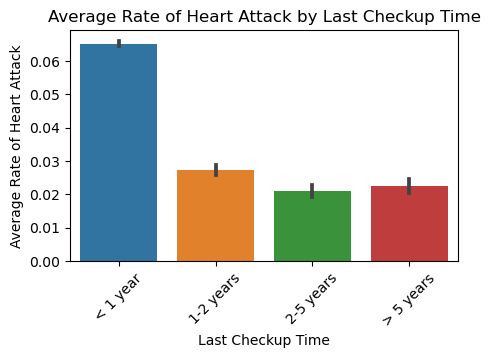

Consequently, I created two separate stacked bar plots, one for individuals who had experienced a heart attack and one for those who had not. This approach aimed to eliminate the confounding variable of having had a heart attack, as each plot’s dataset shared the same characteristic in this regard.

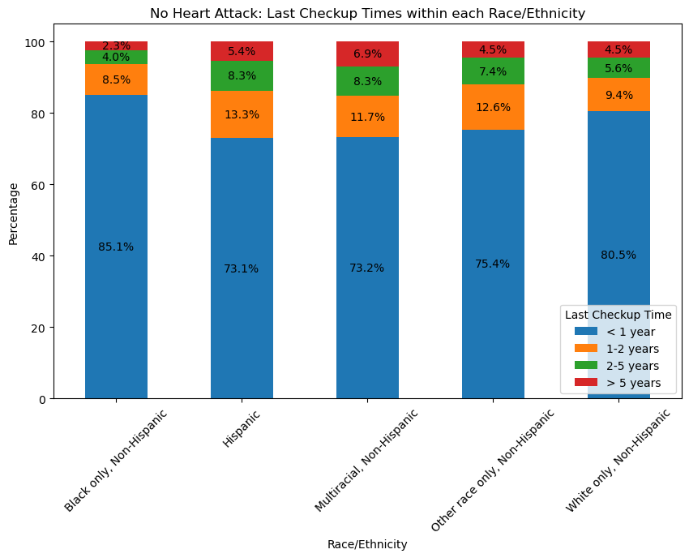

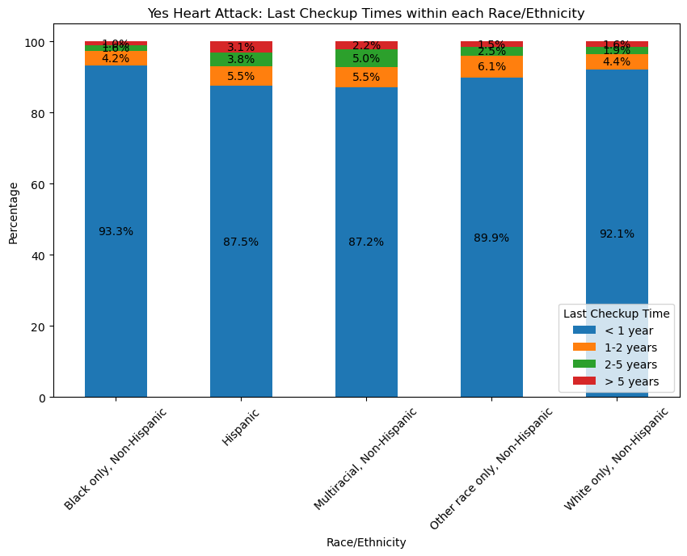

I was able to effectively identify a disparity in checkup frequencies between black and white groups compared to Hispanic, multiracial, and other race groups. This gap, I believe, is primarily due to issues of accessibility. The groups with less access, namely Hispanic, multiracial, and others, consequently have less recent and less frequent checkups. However, upon examining the differences in these groups, taking into account those who have and have not had a heart attack, I also conclude that a portion of the disparity can be attributed to factors such as cultural beliefs, education, and perceptions of healthcare.

### 6.3 Lifestyle Analysis

*By Ethan Sterling*

How do lifestyle choices correlate with the occurrence of heart attacks among individuals in the dataset?

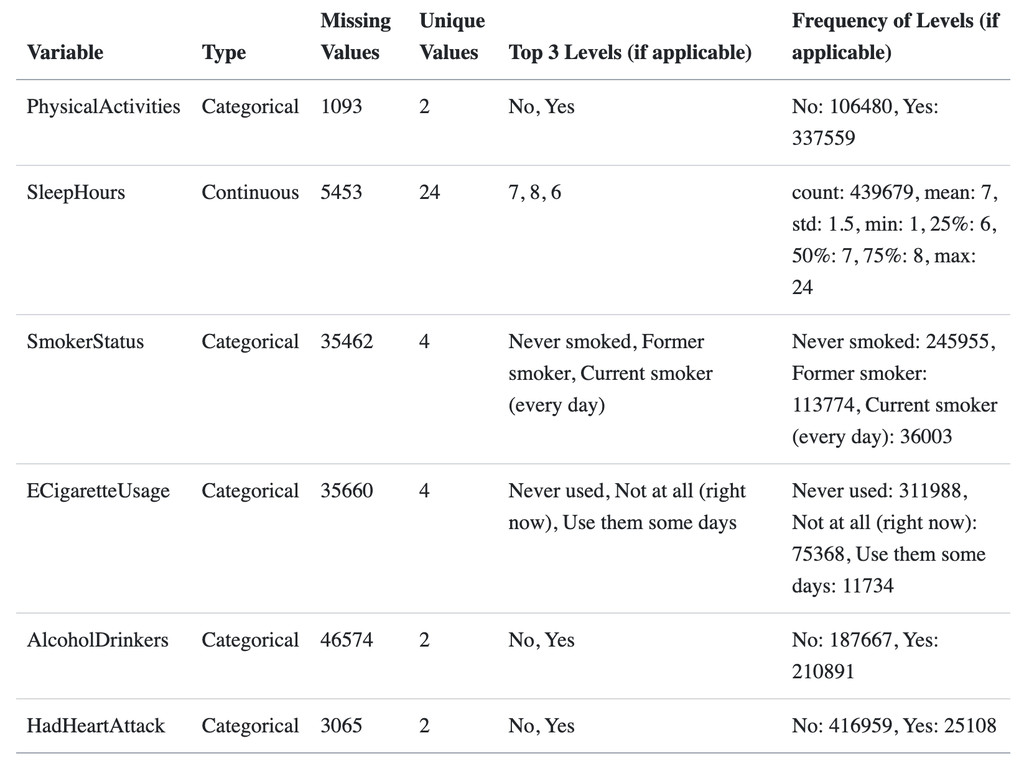

#### 6.3.1 Data Cleaning and Preparation

**Anticipated Problems:** Missing values in the dataset, potential confounding variables influencing correlations, and interpretation challenges due to complex relationships.

**Preparation & Cleaning:** For my analysis, I sliced the dataframe into a subset of only variables I deemed as “lifestyle decisions.” To clean my new dataset, I decided to drop all rows with missing values due to the lack of categorical variables for imputing missing values and the large size of the original data set. Post cleaning there were *386782* entries left, plenty to do EDA. Here are the selected variables and their missing values:

- PhysicalActivities: 1093
- SleepHours: 5453
- SmokerStatus: 35462
- ECigaretteUsage: 35660
- AlcoholDrinkers: 46574
- HadHeartAttack: 3065
- GeneralHealth: 1198

#### 6.3.2 Continuous Variables (SleepHours)

*Let’s first look at the variable SleepHours as it is our only continuous variable in the lifestyle_choices_cleaned dataframe.*

I decided to make a box plot for the distribution of sleep hours among those who had a heart attack and those who did not to visualize any differences between the two categories.

| HadHeartAttack | count | mean | std | min | 25% | 50% | 75% | max |
| --- | --- | --- | --- | --- | --- | --- | --- | --- |
| No | 365017.0 | 7.020588 | 1.445694 | 1.0 | 6.0 | 7.0 | 8.0 | 24.0 |
| Yes | 21765.0 | 7.050448 | 1.915061 | 1.0 | 6.0 | 7.0 | 8.0 | 24.0 |

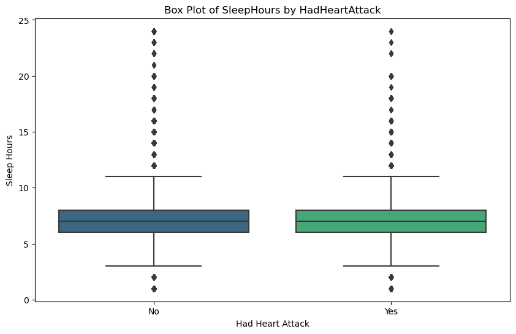

**Here is the result of my significance test:** T-statistic: 2.899, P-value: 0.004, reject the null hypothesis.

**My conclusions about sleep:** The t-test indicates a statistically significant difference in mean sleep hours between individuals who had a heart attack and those who did not. However, it’s important to note that while the difference is statistically significant, the practical significance may be limited given the small difference in means (0.03 hours) and the large sample size. This could be due to older people, who are more likely to have heart attacks, also sleeping more, confounding the SleepHours variable. This could also be due to people who had heart attacks beginning to sleep more.

#### 6.3.3 Categorical Variables

*Now let’s look at the rest of our variables:*

I created proportion plots to illustrate the varying proportions of lifestyle decisions between individuals who experienced heart attacks and those who did not. I also ran a Chi-Square Test to see if these differences were significant or not. It is important to use proportions for this data set as there are a large amount of enteries and much more enteries for people who did not have a heart attack compared to those who did.

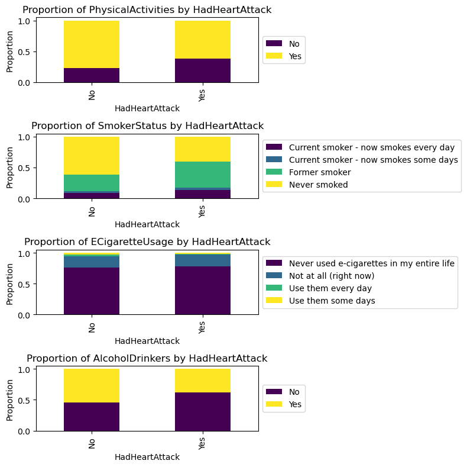

**Results:**

- Physical Activities: Individuals who had a heart attack are less likely to engage in physical activities. A significant association exists between having a heart attack and the level of physical activities.
- Smoker Status: Current smokers, both daily and occasional, show a higher prevalence of heart attacks. A significant association is observed between smoker status and the likelihood of having a heart attack.
- E-Cigarette Usage: Individuals who had a heart attack are less likely to use e-cigarettes. A significant association exists between e-cigarette usage and the likelihood of having a heart attack.
- Alcohol Drinkers: Non-alcohol drinkers show a higher prevalence of heart attacks. A significant association is observed between alcohol drinking habits and the likelihood of having a heart attack.

**Interpretation:** These results suggest that lifestyle choices such as physical activities and smoking habits (both traditional and e-cigarettes), are associated with the likelihood of having a heart attack. One interesting observation is that alcohol consumption has a negative correlation with heart attacks. The significance of these associations emphasizes the importance of lifestyle modifications in heart disease prevention. These findings could inform public health initiatives and personalized interventions to reduce the risk of heart attacks, especially targeting individuals with certain lifestyle behaviors.

**Caution:** While statistically significant, the observed associations do not imply causation. The results are based on observational data, and other confounding factors may contribute to the associations.

#### 6.3.4 Correlations

*Let’s see which of our lifestyle decisions are the most correlated with reducing heart attacks:*

To start, I decided to bin sleep hours into the categories “Very Low,” “Low,” “Moderate,” and “High.” This was so I could look at Cramér’s V, a measure of association between two categorical variables. It is based on the chi-square statistic and provides a value between 0 and 1, where 0 indicates no association, and 1 indicates a perfect association.

**Cramér’s V:**

- PhysicalActivities: 0.087
- SmokerStatus: 0.101
- ECigaretteUsage: 0.023
- AlcoholDrinkers: 0.074
- SleepHoursBin: 0.061

From this we can observe that the order of lifestyle decisions that most correlate with preventing heart attack to least is SmokerStatus, PhysicalActivities, AlcoholDrinkers, SleepHoursBin, ECigaretteUsage.

In addition to Cramér’s V, I also made a new dataframe that created dummy variables for the categorical variables to generate standard correlation statistics. These correlations can be visualized in a heatmap, as seen below. The values back up the claims we made by looking at Cramér’s V.

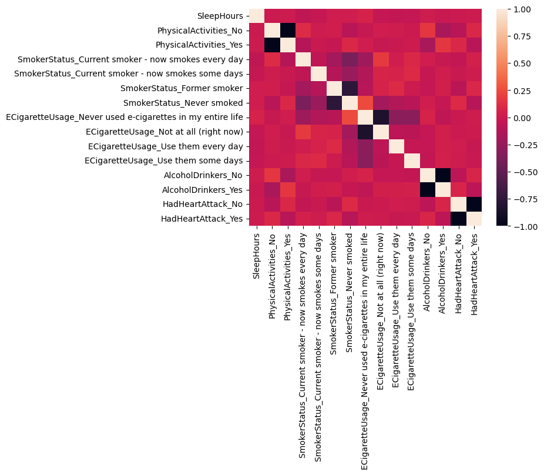

**Some things I found interesting so far:** More sleep is correlated with heart attacks. I believe this is due to confounding variables such as sleep being correlated with age and age being correlated with heart attacks. I will control for age below. In addition, drinking alcohol is correlated with not having heart attacks. I will check what drinking alcohol is correlated with to see if there are any confounding variables.

#### 6.3.5 Controlling for age when looking at sleep’s correlation with heart attacks

I first made sure that there was indeed an upward trend of sleep hours correlating with age. For this, I needed to bring in a new variable, AgeCategory. The relationship is plotted below.

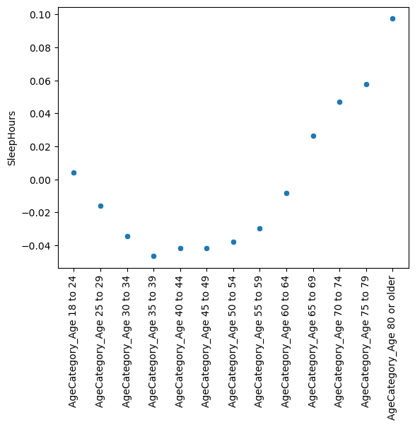

This reveals that, beginning at age 35, individuals tend to sleep longer as they age. Furthermore, we can substantiate the notion that older individuals experience more heart attacks, as suggested by Leshem’s exploratory data analysis on these potential confounding variables.

I started below by remaking a box plot for the distribution of sleep hours among those who had a heart attack and those who did not, but this time, I added a hue of which AgeCategory the subject belonged to. To better visualize this, I remade these box plots, faceted by AgeCategory and ran a significance t-test on the differences between each one.

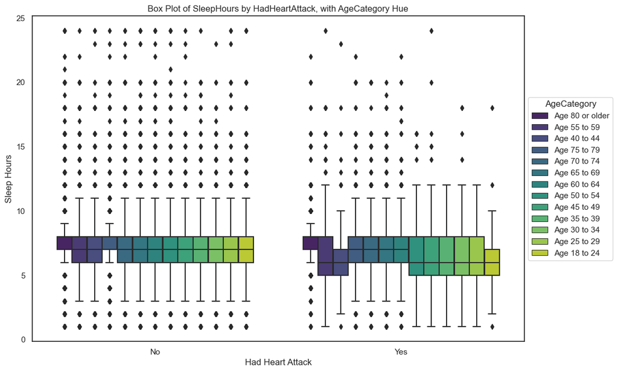

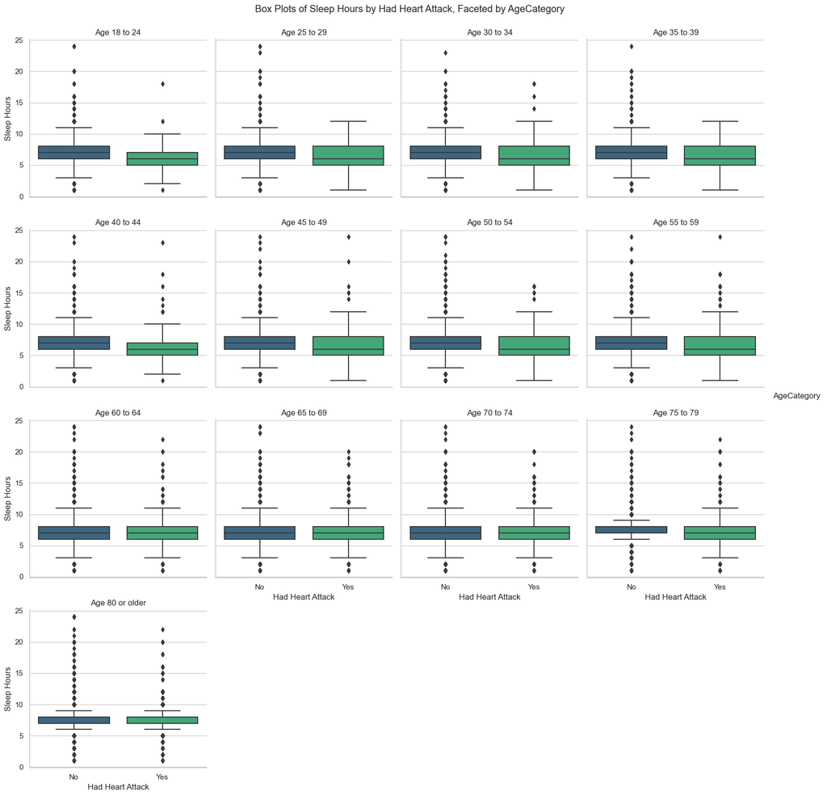

**Age Categories with Significant Differences:** For Age Categories from ‘Age 18 to 64’, the t-tests indicate a significant difference in sleep hours between those who had a heart attack and those who did not. The mean differences are negative, suggesting that, on average, individuals who had a heart attack slept fewer hours than those who did not in these age categories.

**Age Categories without Significant Differences:** For ‘Age 75 to 79’ and ‘Age 80 or older’, the p-values are greater than the significance level (0.05). Therefore, we fail to reject the null hypothesis in these age categories, indicating no significant difference in sleep hours between individuals who had a heart attack and those who did not.

**Conclusion:** From this we can take away that getting more sleep is, in fact, correlated with reducing the risk of a heart attack. On average, individuals who had a heart attack got 0.405 less hours of sleep than those who did not have a heart attack across all age categories. We can also see that getting more sleep at a young age is more important than getting sleep at an older age from the trend in the facet grid. The grid shows that at younger ages, the difference in median between those who had heart attacks and those who did not is much greater than the difference in medians among older age groups.

#### 6.3.6 Finding confounding variables for alcohol consumption

*Wow that was cool! Lets take a look at drinking:*

To search for any variables that might be confounding, I first looked at the correlation between alcohol consumption and other lifestyle decisions from the heatmap above. We can see that alcohol drinkers have noticeable correlations with physical activity, smoking, and e-cigarette usage. I decided to make proportion plots to visualize the relationship between alcohol drinkers and each of these other lifestyle decisions.

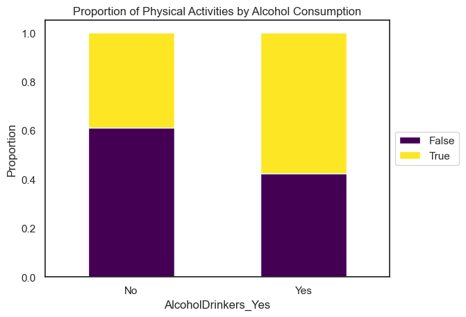

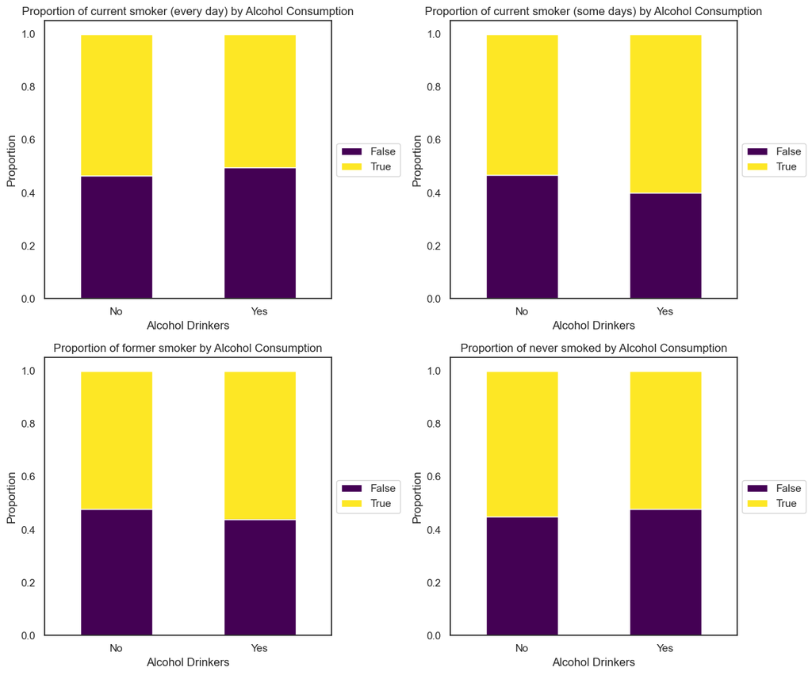

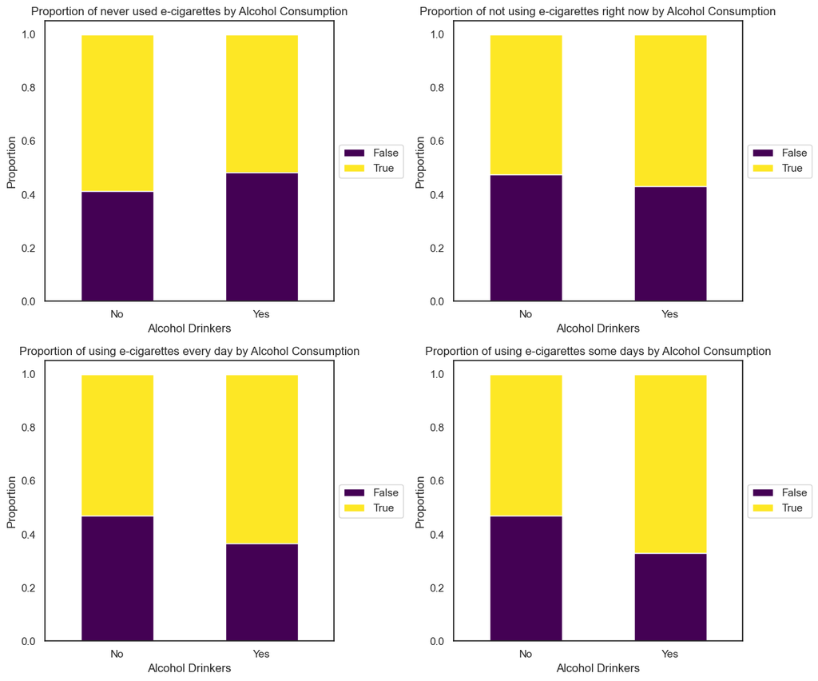

To reinforce this observation, I redesigned the proportion plot to depict the alcohol consumption proportions among individuals with and without heart attacks. This time, the plots were split based on engagement in physical activity.

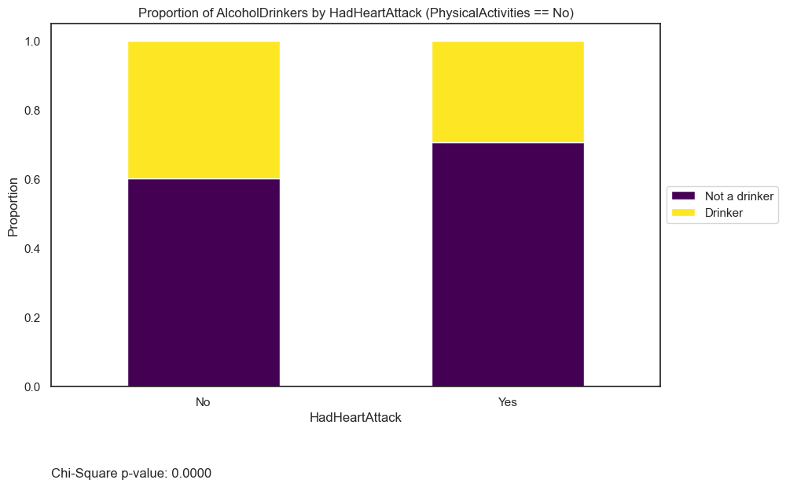

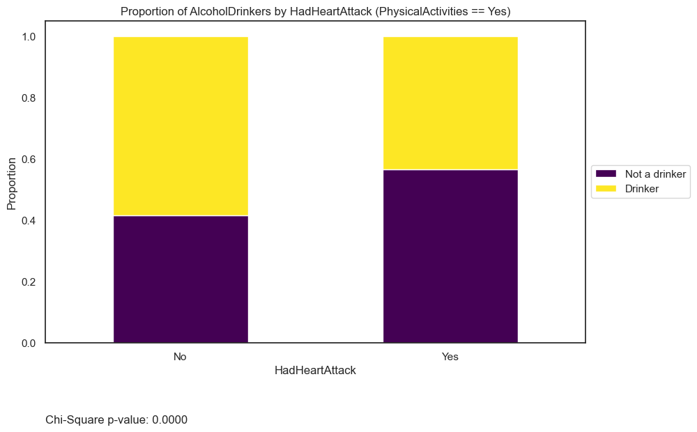

**Result:** From observing the plots, whether or not individuals participated in physical activity or not, those who did not drank alcohol were greater among those who had heart attacks than those who did not. The p-values are less than 0.05 for both (PhysicalActivities == Yes) and (PhysicalActivities == No), meaning that drinking alcohol still has a positive correlation with not having a heart attack. Interesting! This observation is supported by an article in The Harvard Gazette.<sup>1</sup>

### 6.4 Underlying Conditions and BMI Analysis

*By Fauzan Aryaputra*

#### 6.4.1 Data Cleaning and Preparation

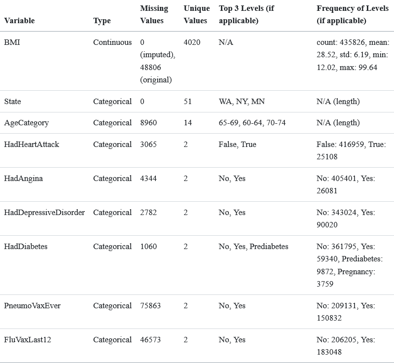

- For missing values, the nature of the collection of the data had no indications of being missing not at random (alternatively phrased, missing values are missing completely at random) as the collection of information was through phone call and all phone calls had a standardized script from the CDC. I decided that it would be safe to assume that all missing data was missing completely at random, hence null values would be safe to eliminate.
- For missing values of BMI, however, I imputed them with the mean value of the BMI of the state from which the observation originated. I explain this reasoning later.
- For TetanusLast10Tdap, the values were either 3 slightly different forms of “yes”, or “no”, so I cleaned it to make it a binary variable.
- For HadHeartAttack, I changed its values from Yes and No to boolean values True and False in order to be compatible with the map interface I used.

#### 6.4.2 List of Interested Variables

- BMI
- State
- AgeCategory
- HadHeartAttack
- HadAngina
- HadDepressiveDisorder
- HadDiabetes
- PneumoVaxEver
- FluVaxLast12
- TetanusLast10Tdap

There were missing values for all the categorical variables to some degree. In my analysis, I only ever chose to analyze three variables at a time, and each time I decided to do so, I only dropped the null values in the selected variables instead of the rest of the dataframe to preserve accuracy. I chose to drop null values as there was no indication of MNAR data in its collection method and imputation with binary values seemed too inacccurate and unnecessary, especially given the fact that there would still be 350,000+ observations after dropping the null values for the variable with the most null values. Not to mention that if I did pursue KNN imputation in my binary values I would have to compute through nearly 450,000 values.

I was, however, intrigued at whether I could impute the continuous BMI values. I hypothesized that culture and cuisines within states would lead to similar BMIs within a state, and could use the result of an ANOVA test to verify whether there is a statistically significant relationship. I chose not to do KNN imputation as the computational complexity of comparing with 400,000+ variables would not be worth the marginal difference in accuracy.